# Statistical Inference Course Project - Part 1

Michael Steiner

October 11, 2017

## Overview

This project investigate the exponential distribution in R and compare it to the Central limit Theorem. The exponential distribution can be simulated in R with rexp(n, lambda) where lambda is the rate parameter. The mean of exponential distribution is 1/lambda and the standard deviation is also 1/lambda. Lambda is set to 0.2 for all simulations. This report will investigate the distribution of averages of 40 exponentials for 1000 simulations.

## Simulation

```r
set.seed(22)
lambda <- 0.2
exp <- 40
simulations <- 1000
```

With lambda set to `0.2`, the exponential distribution and the standard deviation are both `5`.

```r
sim_means <- c()
for (i in 1:simulations){
  sim_means <- c(sim_means, mean(rexp(exp, lambda)))
}
```

## Sample Mean versus Theoretical Mean

The sample mean is `4.989` compared to the theoretical mean of `5`. This is a difference of `0.22`%

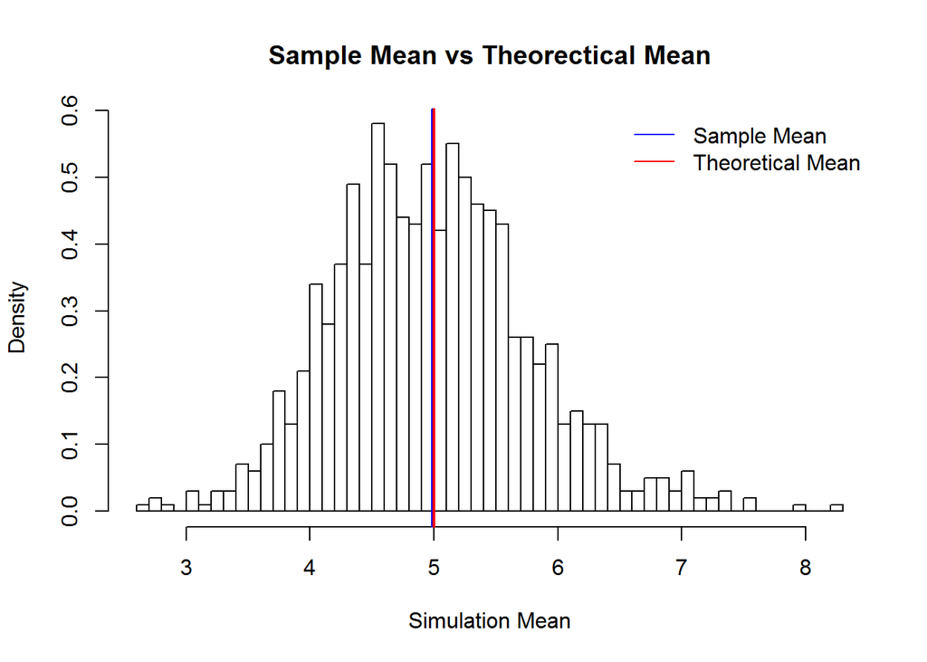

```r
hist(sim_means,
    breaks = 50,
    prob = TRUE,
    main="Sample Mean vs Theorectical Mean",
    xlab="Simulation Mean")

abline(v = mean(sim_means), col= 'blue',lwd = 2)
abline(v = 1/lambda, col = 'red',lwd = 2)

legend('topright', c("Sample Mean", "Theoretical Mean"),bty = "n", lty = c(1,1), col = c(col = 'blue', col = 'red'))
```

## sample Variance vs Theoretical Variance

The varience of the sample is an estimate of the variance of the population using the number of samples.

```r
sample_var <- var(sim_means)
pop_var<- (1/lambda)^2/40
```

The population variance is `0.625` and the sample variance is `0.6337023`.

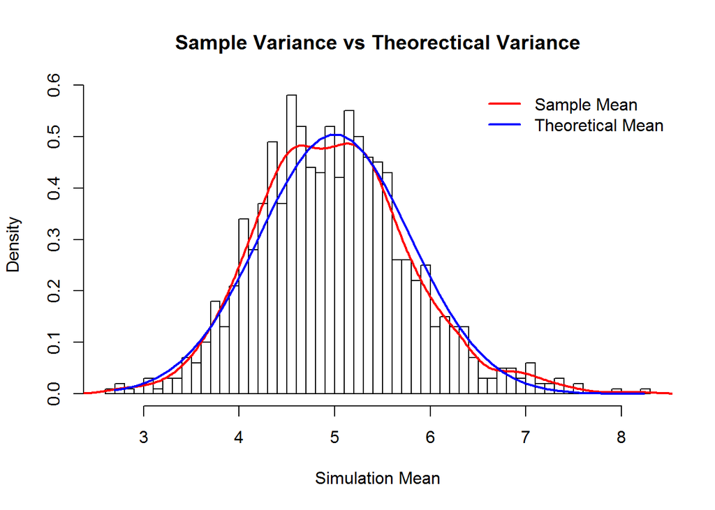

```r
hist(sim_means,
    breaks = 50,
    prob = TRUE,
    main="Sample Variance vs Theorectical Variance",
    xlab="Simulation Mean")


legend('topright', c("Sample Mean", "Theoretical Mean"), bty = "n", lwd = c(2,2), col = c(col = 'red', col = 'blue'))

lines(density(sim_means), col = 'red', lwd = 2)
xfit <- seq(min(sim_means), max(sim_means), length = 50)
yfit <- dnorm(xfit, mean = 1/lambda, sd = (1/lambda/sqrt(40)))
lines(xfit, yfit, col = 'blue', lwd = 2)
```

## Distribution

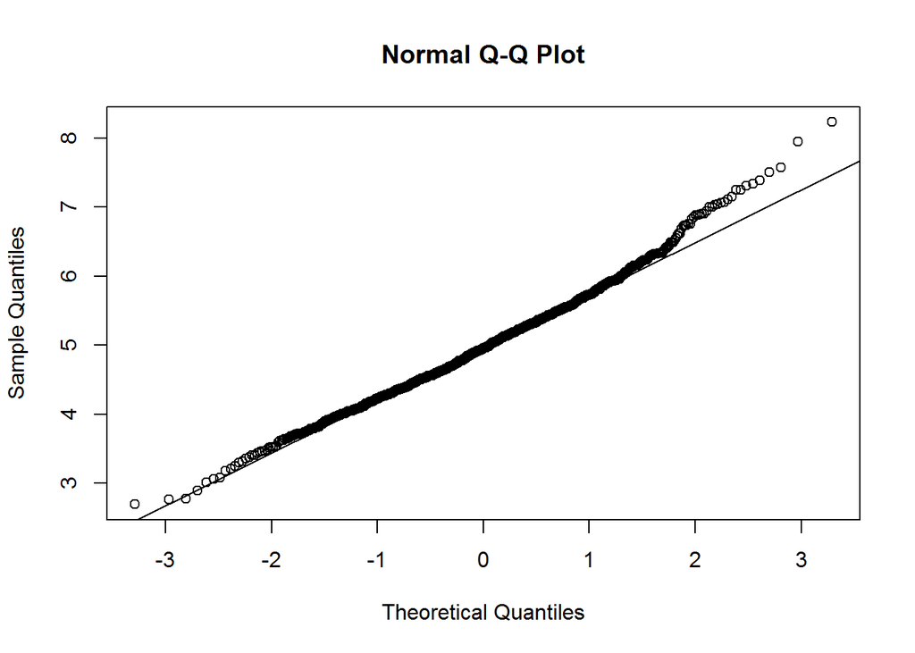

```r
qqnorm(sim_means)
qqline(sim_means)
```